# FinalProject_Browne

2023-11-04

## Introduction

CIC-DUX4 Sarcoma (CDS) is a high-grade sarcoma associated with high rates of metastasis, chemoresistance, and poor outcomes. This project utilizes RNA sequencing data to compare CDS to other types of sarcoma through the use of heat maps, PCA plots and targeted expression analysis. Here my analysis compares CDS cell lines to non-CDS cell lines by:

```
1. Reorgainizing data
2. Using DESeq2 to define top varibaly expressed genes
3. Generating PCA plots
4. Visualizing exrpression of SHC3 and SHC4 in CDS and non-CDS cell lines
```

From this analysis, I was able to define SHC3 and SHC4 as two genes uniquely over expressed in CDS cells. Additionally, this analysis shows human CDS cell lines cluster together and away from other types of sarcoma cell lines, providing further evidence that CDS is distinct from other sarcoma sub-types.

## Data Set Up and Organization

```r
cdscts <- read_csv("combinedhumanCDS.csv")
dim(cdscts)
```

```
## [1] 1873760      11
```

```r
head(cdscts)
```

```
## # A tibble: 6 × 11
##   ensgene         entrez symbol chr      start    end strand biotype description
##   <chr>            <dbl> <chr>  <chr>    <dbl>  <dbl>  <dbl> <chr>   <chr>
## 1 ENSG00000000003   7105 TSPAN6 X       1.01e8 1.01e8     -1 protei… tetraspani…
## 2 ENSG00000000003   7105 TSPAN6 X       1.01e8 1.01e8     -1 protei… tetraspani…
## 3 ENSG00000000003   7105 TSPAN6 X       1.01e8 1.01e8     -1 protei… tetraspani…
## 4 ENSG00000000003   7105 TSPAN6 X       1.01e8 1.01e8     -1 protei… tetraspani…
## 5 ENSG00000000003   7105 TSPAN6 X       1.01e8 1.01e8     -1 protei… tetraspani…
## 6 ENSG00000000003   7105 TSPAN6 X       1.01e8 1.01e8     -1 protei… tetraspani…
## # ℹ 2 more variables: cell_lines <chr>, counts <dbl>
```

```r
cdsdata <- cdscts %>%
  dplyr::select(ensgene,symbol,cell_lines,counts)
head(cdsdata)
```

```
## # A tibble: 6 × 4
##   ensgene         symbol cell_lines counts
##   <chr>           <chr>  <chr>       <dbl>
## 1 ENSG00000000003 TSPAN6 X1C1.1        306
## 2 ENSG00000000003 TSPAN6 X1C1.2        300
## 3 ENSG00000000003 TSPAN6 X3C1.1        280
## 4 ENSG00000000003 TSPAN6 X3C1.2        342
## 5 ENSG00000000003 TSPAN6 CDS2.1        329
## 6 ENSG00000000003 TSPAN6 CDS2.2        151
```

```r
cdsdata %>%
  group_by(cell_lines) %>%
  summarise(num_genes = n())
```

```
## # A tibble: 28 × 2
##    cell_lines num_genes
##    <chr>          <int>
##  1 A673           66920
##  2 Aska           66920
##  3 BER            66920
##  4 CDS2.1         66920
##  5 CDS2.2         66920
##  6 ECD1.1         66920
##  7 ECD1.2         66920
##  8 JN             66920
##  9 Kitra.1        66920
## 10 Kitra.2        66920
## # ℹ 18 more rows
```

```r
cpm <- reshape2::dcast(cdsdata,ensgene~cell_lines, fun.aggregate = sum, value.var = "counts")
cpm <- column_to_rownames(cpm, var = "ensgene")
dim(cpm)
```

```
## [1] 62702    28
```

```r
cpm[1:10,1:5]
```

```
##                 A673 Aska  BER CDS2.1 CDS2.2
## ENSG00000000003 1150  972 1156    329    151
## ENSG00000000005    0    0    1      0      0
## ENSG00000000419 1391 1578 1483   1343   1415
## ENSG00000000457  339  167  321    168    171
## ENSG00000000460  271  299  733    160    211
## ENSG00000000938    2    0    0      0      0
## ENSG00000000971   18   25   33     53     40
## ENSG00000001036  804 3695 3739    792   1026
## ENSG00000001084  570 1267 1945    317    392
## ENSG00000001167 1501 2616 1134   1569    912
```

```r
library(DESeq2)
#categorizing cell lines based on sarcoma type

#CIC-DUX4 sarcoma
CDS <- c("X1C1.1",
"X1C1.2",
"X3C1.1",
"X3C1.2",
"CDS2.1",
"CDS2.2",
"PDX1.1",
"PDX1.2",
"PDX3.1",
"PDX3.2",
"Kitra.1",
"Kitra.2",
"ECD1.1",
"ECD1.2",
"TE441T.1",
"TE441T.2")

#Fusion-positive rhabdomyosarcoma
FP_RMS <- c("Rh28",
"Rh30",
"Rh4")

#Fusion-negative rhabdomyosarcoma
FN_RMS <- c("SMS-CTR",
"RD")

#Ewing sarcoma
RS <- c("RDES",
"A673")

#Desmoplastic small round cell tumors
DSRCT <- c("BER",
"JN")

#synovial sarcoma
SS <- c("SYO",
"Yamoto",
"Aska")

#Classifying cell lines as 'CDS' 'Other sarcoma'
condition <- ifelse(colnames(cpm) %in% CDS, "CDS", "Other Sarcoma")
colData_input <- as.data.frame(condition)
rownames(colData_input) <- colnames(cpm)



# **Differential Gene Expression Analysis**

library(DESeq2)
dds <- DESeqDataSetFromMatrix(countData = cpm,
                              colData = colData_input,
                              design = ~condition)
dds <- DESeq(dds)
results(dds, contrast = c("condition","Other Sarcoma","CDS"))
```

```
## log2 fold change (MLE): condition Other Sarcoma vs CDS
## Wald test p-value: condition Other.Sarcoma vs CDS
## DataFrame with 62702 rows and 6 columns
##                    baseMean log2FoldChange     lfcSE      stat      pvalue
##                   <numeric>      <numeric> <numeric> <numeric>   <numeric>
## ENSG00000000003  595.120358      1.3270540  0.395938  3.351667 8.03265e-04
## ENSG00000000005    0.927983      2.4711552  1.642970  1.504078 1.32561e-01
## ENSG00000000419 1370.471447      0.2025479  0.152855  1.325097 1.85139e-01
## ENSG00000000457  240.056620      0.0728106  0.130628  0.557391 5.77261e-01
## ENSG00000000460  346.931959      1.4237690  0.199011  7.154227 8.41459e-13
## ...                     ...            ...       ...       ...         ...
## ENSG00000291297    0.000000             NA        NA        NA          NA
## ENSG00000291298    0.000000             NA        NA        NA          NA
## ENSG00000291299   34.482098      -0.656641  0.243785 -2.693529 7.07001e-03
## ENSG00000291300   29.185922      -5.727732  0.901406 -6.354217 2.09490e-10
## ENSG00000291301    0.189689       1.169782  3.014942  0.387995 6.98020e-01
##                        padj
##                   <numeric>
## ENSG00000000003 3.74258e-03
## ENSG00000000005 2.38665e-01
## ENSG00000000419 3.07121e-01
## ENSG00000000457 6.99459e-01
## ENSG00000000460 3.35759e-11
## ...                     ...
## ENSG00000291297          NA
## ENSG00000291298          NA
## ENSG00000291299 2.32392e-02
## ENSG00000291300 5.27445e-09
## ENSG00000291301          NA
```

```r
generate_DE_results <- function(dds, comparisons, padjcutoff = 0.001)
# extract DESeq results between comparisons indicated
{
res <- results(dds, contrast = c("condition", comparisons[1],comparisons[2]))[,-c(3,4)]
# annotate the data with gene name
res <- as_tibble(res, rownames = "ensembl_id")
my_annoation <- read.csv("GRCh38.p13_annotation.csv", header = TRUE, stringsAsFactors = FALSE)
res <- left_join(res, my_annoation, by = c("ensembl_id" = "Gene.stable.ID"))
# combine normalized counts with entire DE lsit
normalized_counts <- round(counts(dds, normalized = TRUE),3)
combined_data <- as_tibble(cbind(res, normalized_counts))
combined_data <- combined_data[order(combined_data$log2FoldChange, decreasing= TRUE),]
#generate sorted lists with the indicated cutoff values
res <- res[order(res$log2FoldChange, decreasing = TRUE),]
           de_genes_padj <- res[which(res$padj < padjcutoff), 1]
# write output to files
write.csv (de_genes_padj, file = paste0(comparisons[1], "_vs_", comparisons[2], "_padj_cutoff.csv"), row.names = FALSE)
write.csv (combined_data, file = paste0(comparisons[1], "_vs_", comparisons[2], "_allgenes.csv"), row.names = FALSE)

  writeLines( paste0("For the comparison: ", comparisons[1], "_vs_", comparisons[2], "\n",
                     "Out of ", nrow(combined_data), " genes, ", nrow(de_genes_padj), " were below padj ", padjcutoff, "\n",
                     "Gene lists ordered by log2fchange have been generated.") )}

generate_DE_results(dds, c("Other Sarcoma", "CDS"), padjcutoff = 0.001)
```

```
## For the comparison: Other Sarcoma_vs_CDS
## Out of 62702 genes, 5020 were below padj 0.001
## Gene lists ordered by log2fchange have been generated.
```

```r
# **Generating visualizations**
results(dds, contrast = c("condition","Other Sarcoma","CDS"))
```

```
## log2 fold change (MLE): condition Other Sarcoma vs CDS
## Wald test p-value: condition Other.Sarcoma vs CDS
## DataFrame with 62702 rows and 6 columns
##                    baseMean log2FoldChange     lfcSE      stat      pvalue
##                   <numeric>      <numeric> <numeric> <numeric>   <numeric>
## ENSG00000000003  595.120358      1.3270540  0.395938  3.351667 8.03265e-04
## ENSG00000000005    0.927983      2.4711552  1.642970  1.504078 1.32561e-01
## ENSG00000000419 1370.471447      0.2025479  0.152855  1.325097 1.85139e-01
## ENSG00000000457  240.056620      0.0728106  0.130628  0.557391 5.77261e-01
## ENSG00000000460  346.931959      1.4237690  0.199011  7.154227 8.41459e-13
## ...                     ...            ...       ...       ...         ...
## ENSG00000291297    0.000000             NA        NA        NA          NA
## ENSG00000291298    0.000000             NA        NA        NA          NA
## ENSG00000291299   34.482098      -0.656641  0.243785 -2.693529 7.07001e-03
## ENSG00000291300   29.185922      -5.727732  0.901406 -6.354217 2.09490e-10
## ENSG00000291301    0.189689       1.169782  3.014942  0.387995 6.98020e-01
##                        padj
##                   <numeric>
## ENSG00000000003 3.74258e-03
## ENSG00000000005 2.38665e-01
## ENSG00000000419 3.07121e-01
## ENSG00000000457 6.99459e-01
## ENSG00000000460 3.35759e-11
## ...                     ...
## ENSG00000291297          NA
## ENSG00000291298          NA
## ENSG00000291299 2.32392e-02
## ENSG00000291300 5.27445e-09
## ENSG00000291301          NA
```

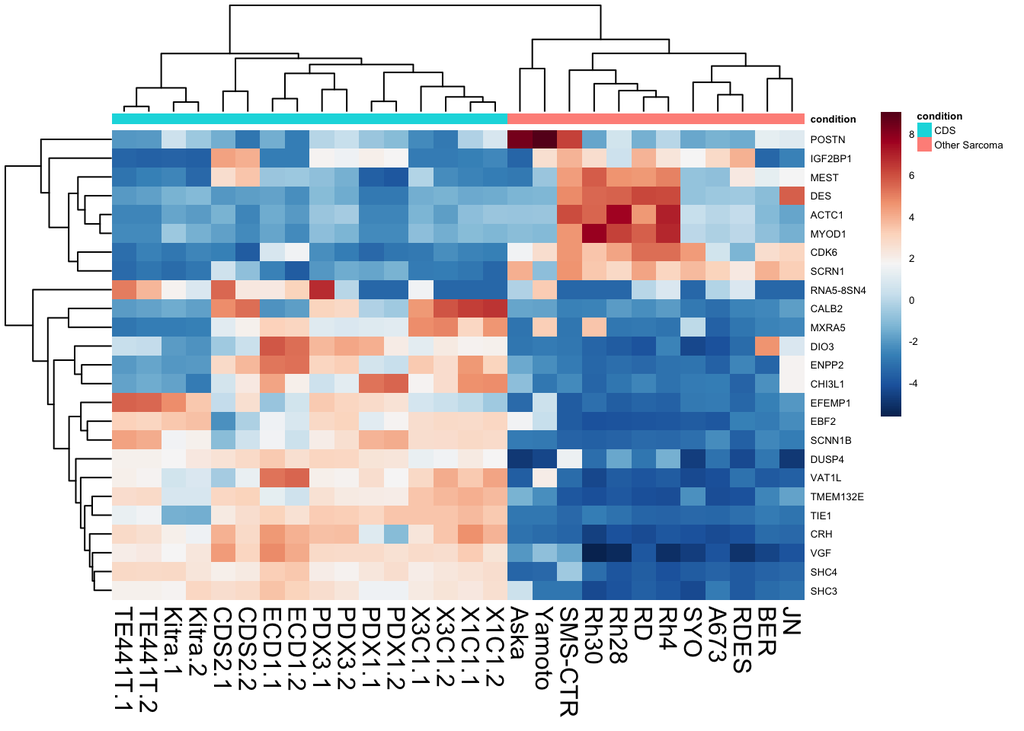

```r
#Heat Map
variable_gene_heatmap <- function (dds, num_genes = 500) {
  vsd.obj <- vst(dds, blind = TRUE)
  brewer_palette <- "RdBu"
  # Ramp the color in order to get the scale.
  ramp <- colorRampPalette( RColorBrewer::brewer.pal(11, brewer_palette))
  mr <- ramp(256)[256:1]
  # get the stabilized counts from the vsd object
  stabilized_counts <- assay(vsd.obj)
  # calculate the variances by row(gene) to find out which genes are the most variable across the samples.
  row_variances <- rowVars(stabilized_counts)
  # get the top most variable genes
  top_variable_genes <- stabilized_counts[order(row_variances, decreasing=T)[1:num_genes],]
  # subtract out the means from each row, leaving the variances for each gene
  top_variable_genes <- top_variable_genes - rowMeans(top_variable_genes, na.rm=T)
  # replace the ensembl ids with the gene names
  annotation <- read.csv("GRCh38.p13_annotation.csv", header = T, stringsAsFactors = F)
  gene_names <- annotation$Gene.name[match(rownames(top_variable_genes), annotation$Gene.stable.ID)]
  rownames(top_variable_genes) <- gene_names
  # reconstruct colData without sizeFactors for heatmap labeling
  coldata <- as.data.frame(vsd.obj@colData)
  coldata$sizeFactor <- NULL
  coldata$replaceable <- NULL
  # draw heatmap using pheatmap
  pheatmap::pheatmap(top_variable_genes, color = mr, annotation_col = coldata, fontsize_col = 12, fontsize_row = 5, border_color = NA, fontsize = 5)
}

variable_gene_heatmap(dds, num_genes = 25)
```

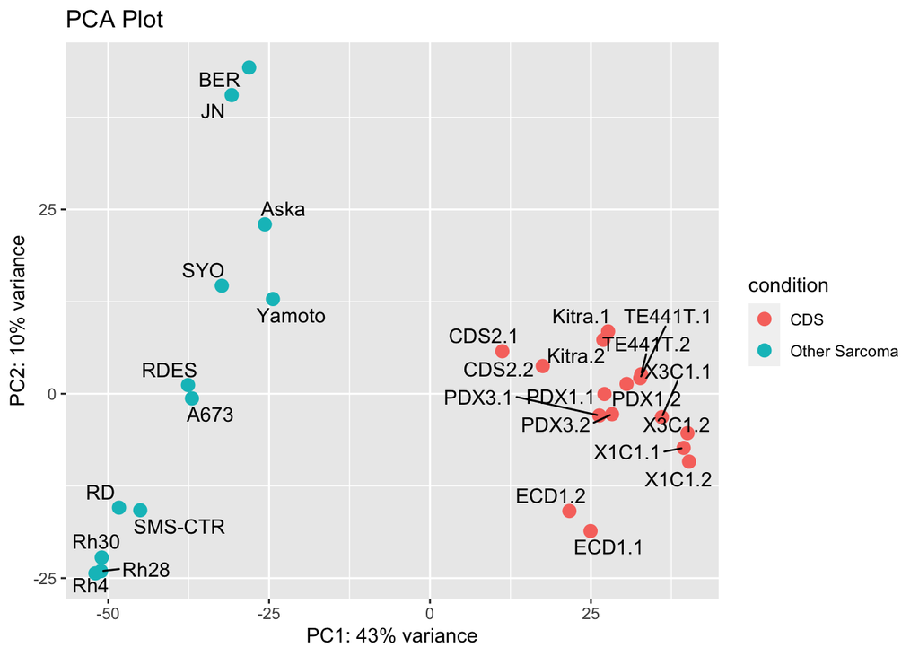

```r
#PCA Plot
library(ggrepel)
plot_PCA = function (dds) {
  vsd.obj <- vst(dds, blind = TRUE)
  pcaData <- plotPCA(vsd.obj,  intgroup = c("condition"), returnData = T)
  percentVar <- round(100 * attr(pcaData, "percentVar"))
  ggplot(pcaData, aes(PC1, PC2, color=condition)) +
    geom_point(size=3) +
    labs(x = paste0("PC1: ",percentVar[1],"% variance"),
         y = paste0("PC2: ",percentVar[2],"% variance"),
         title = "PCA Plot") +
    ggrepel::geom_text_repel(aes(label = name), color = "black")
}
plot_PCA(dds)
```

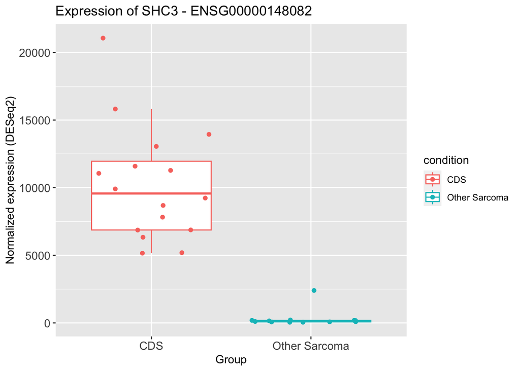

```r
# SHC3 Box Plot
plot_counts <- function (dds, gene){
  annotation <- read.csv("GRCh38.p13_annotation.csv", header = TRUE, stringsAsFactors = FALSE)
  normalized_data <- counts(dds, normalized = TRUE)
  condition <- dds@colData$condition
  # get the gene name from the ensembl id
  if (gene %in% annotation$Gene.name){ # check if a gene name is supplied
    ensembl_id <- annotation$Gene.stable.ID[which(annotation$Gene.name == gene)]
  } else if (gene %in% annotation$Gene.stable.ID){
    ensembl_id <- gene
  } else {
    stop("Gene not found. Check spelling.")
  }

  expression <- normalized_data[ensembl_id,]
  gene_name <- annotation$Gene.name[which(annotation$Gene.stable.ID == ensembl_id)]
  gene_tib <- tibble(condition = condition, expression = expression)
  ggplot(gene_tib, aes(x = condition, y = expression, col = condition))+
    geom_boxplot(outlier.shape = NA)+
    geom_jitter()+
    labs (title = paste0("Expression of ", gene_name, " - ", ensembl_id),
          x = "Group", y = paste("Normalized expression (DESeq2)"))+
    theme(axis.text.x = element_text(size = 11), axis.text.y = element_text(size = 11))
}
plot_counts(dds, "SHC3")
```

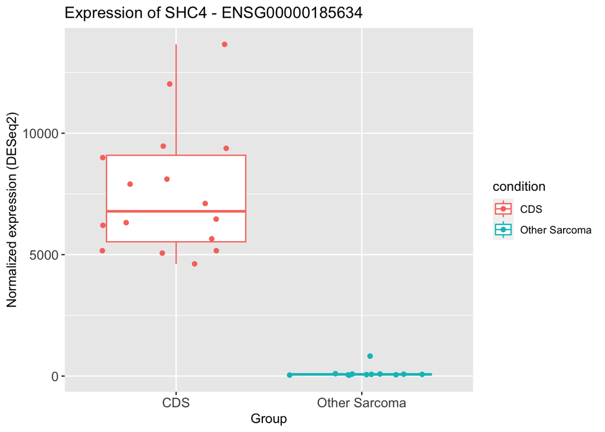

```r
# SHC4 Box Plot
plot_counts(dds, "SHC4")
```

## Summary

In this project, RNA sequencing data was used to compare the transcriptional profile of CDS cells to other sub-types of sarcoma. Prior to analysis, count tables were reorganized to include Ensembl gene name, gene symbol, cell line, and count. Next, a matrix was formed using the dcast function from the reshape2 package to create a table of counts for each cell line. To define genes that are unique to CDS, cell lines were characterized as either “CDS” or as “Other Sarcoma”, then DESeq2 was used for differential gene expression analysis.

**PCA Plot** Considering CDS is now recognized as it’s own entity, it is important to validate that the human CDS cell lines used in this study are distict from the other sarcoma cell lines. Based off the PCA plot analysis, CDS cell lines clustered together and away from the other sarcoma cell lines. Furthermore, the PCA plot demonstrated that sarcoma cell lines of the same sarcoma type clustered together (sub-type labled not shown in PCA, but were grouped in code).

**Box Plot** Previous studies have shown adaptor proteins SHC3 and SHC4 play a role in other, non-sarcoma, cancer metastasis. To visualize the expression of these genes more closely, box plots were generated comparring SHC3/4 expression in CDS cells to other sarcoma cells. Based of this analysis, there is a clear difference in expression between CDS and non-CDS sarcoma cells.

## Refrences

@cite https://erilu.github.io/cell-line-transcriptome-analysis/